# Fitting LMEs to ERP Data: Face-Emotion (Nc) Walkthrough

Simulated data, the 9 steps to building an LME, interpretation, and common errors

2026-10-12

# 1 Overview

In this tutorial, we will:

1. Simulate a small ERP dataset with a hierarchical study design (trials nested in stimuli/conditions, nested in participants).
2. Walk through the 9 steps to building an LME: from the maximal model, simplified until it converges, through checking assumptions and visualizing the results.
3. Interpret the final model’s fixed and random effects, and see how centering and coding (dummy vs. effects) change what the coefficients mean.
4. Illustrate common issues with LMEs (non-convergence, mis-specified random effects, REML vs. ML comparisons) so you recognize these errors and know how to fix them in your own data.
5. Go through some more examples of centering predictors (grand-mean centering vs. centering within cluster).

# 2 Simulating an ERP Study

## 2.1 Study design

Children aged 3–5 years view faces expressing two emotions (“happy” and “angry”), each expression displayed by several different actors, with each actor/emotion combination repeated across 10 trials (a fully-crossed design where every participant sees every actor express every emotion the same number of times). Each child’s age (in years) is a participant-level variable: one value per child.

```r
# Study design parameters --------------------------------------------------
n_subjects       <- 40      # number of participants
n_actors         <- 5       # number of actors per emotion condition
n_presentations  <- 10      # number of times each actor/emotion is shown
emotion_labels   <- c("Happy", "Angry")

# Population-level parameters
mean_amp_happy   <- -10     # population NC mean amplitude for Happy (microvolts)
mean_amp_angry   <- -12     # population NC mean amplitude for Angry (microvolts)
decay_per_trial  <- 0.5     # amplitude becomes *less* negative by this much per presentation (habituation)
age_effect       <- -2      # amplitude becomes *more* negative by this much per year of age,
                            # averaged over emotions (older children have larger NCs)
emotion_age_int  <- 1.5     # the Happy - Angry difference grows by this much per year of age
                            # (0.5 µV at age 3, 2 µV at age 4, 3.5 µV at age 5)
subject_sd       <- 10      # SD of random intercepts across participants
actor_sd         <- 5       # SD of random intercepts across actors
trial_noise_sd   <- 8       # single-trial (residual) noise SD

set.seed(425)
```

## 2.2 Building the trial-level dataset

We simulate one row per trial. We simulate random intercepts for each participant and each actor (stimulus feature). In addition, we simulate additional trial-level noise.

```r
subject_ids <- sprintf("%02d", 1:n_subjects)
actor_ids   <- sprintf("%02d", 1:n_actors)

# Random effects: one random intercept per participant, one per actor
# Each participant also gets one age (years), drawn uniformly between 3 and 5
subject_re <- tibble(SubjectID = subject_ids,
                      subj_intercept = rnorm(n_subjects, mean = 0, sd = subject_sd),
                      AgeYears = round(runif(n_subjects, min = 3, max = 5), 1))

actor_re <- tibble(ActorID = actor_ids,
                    actor_intercept = rnorm(n_actors, mean = 0, sd = actor_sd))

# Full trial-level grid: every participant x every actor x every emotion x every presentation
sim_data <- expand_grid(
  SubjectID  = subject_ids,
  Emotion    = emotion_labels,
  ActorID    = actor_ids,
  PresentNum = 1:n_presentations
) %>%
  left_join(subject_re, by = "SubjectID") %>%
  left_join(actor_re, by = "ActorID") %>%
  mutate(
    emotion_effect = case_when(Emotion == "Happy" ~ mean_amp_happy,
                               Emotion == "Angry" ~ mean_amp_angry),
    # amplitude habituates (becomes less negative) across repeated presentations;
    # centered on the middle presentation so the emotion_effect above stays
    # interpretable as the mean amplitude at an "average" presentation number
    decay_effect = decay_per_trial * (PresentNum - mean(1:n_presentations)),
    # older children have larger (more negative) amplitudes; centered on age 4
    age_shift = age_effect * (AgeYears - 4),
    # Emotion x Age interaction: the Happy - Angry difference grows with age
    # (half of the interaction added to Happy, half subtracted from Angry, so the
    # age effect averaged over emotions is still age_effect)
    emotion_age_shift = if_else(Emotion == "Happy", 0.5, -0.5) * emotion_age_int * (AgeYears - 4),
    trial_noise = rnorm(n(), mean = 0, sd = trial_noise_sd),
    MeanAmp = emotion_effect + decay_effect + age_shift + emotion_age_shift +
      subj_intercept + actor_intercept + trial_noise
  )

glimpse(sim_data)
```

```
## Rows: 4,000
## Columns: 13
## $ SubjectID         <chr> "01", "01", "01", "01", "01", "01", "01", "01", "01", "01", "01", "01", "01", "01", "01", "0…
## $ Emotion           <chr> "Happy", "Happy", "Happy", "Happy", "Happy", "Happy", "Happy", "Happy", "Happy", "Happy", "H…
## $ ActorID           <chr> "01", "01", "01", "01", "01", "01", "01", "01", "01", "01", "02", "02", "02", "02", "02", "0…
## $ PresentNum        <int> 1, 2, 3, 4, 5, 6, 7, 8, 9, 10, 1, 2, 3, 4, 5, 6, 7, 8, 9, 10, 1, 2, 3, 4, 5, 6, 7, 8, 9, 10,…
## $ subj_intercept    <dbl> 2.735957, 2.735957, 2.735957, 2.735957, 2.735957, 2.735957, 2.735957, 2.735957, 2.735957, 2.…
## $ AgeYears          <dbl> 3.9, 3.9, 3.9, 3.9, 3.9, 3.9, 3.9, 3.9, 3.9, 3.9, 3.9, 3.9, 3.9, 3.9, 3.9, 3.9, 3.9, 3.9, 3.…
## $ actor_intercept   <dbl> 3.050106, 3.050106, 3.050106, 3.050106, 3.050106, 3.050106, 3.050106, 3.050106, 3.050106, 3.…
## $ emotion_effect    <dbl> -10, -10, -10, -10, -10, -10, -10, -10, -10, -10, -10, -10, -10, -10, -10, -10, -10, -10, -1…
## $ decay_effect      <dbl> -2.25, -1.75, -1.25, -0.75, -0.25, 0.25, 0.75, 1.25, 1.75, 2.25, -2.25, -1.75, -1.25, -0.75,…
## $ age_shift         <dbl> 0.2, 0.2, 0.2, 0.2, 0.2, 0.2, 0.2, 0.2, 0.2, 0.2, 0.2, 0.2, 0.2, 0.2, 0.2, 0.2, 0.2, 0.2, 0.…
## $ emotion_age_shift <dbl> -0.075, -0.075, -0.075, -0.075, -0.075, -0.075, -0.075, -0.075, -0.075, -0.075, -0.075, -0.0…
## $ trial_noise       <dbl> -6.35422856, 0.08203749, -1.04179424, 0.83310472, 0.01687214, 10.13381064, 0.25953738, 3.629…
## $ MeanAmp           <dbl> -12.6931655, -5.7568994, -6.3807311, -4.0058322, -4.3220647, 6.2948738, -3.0793995, 0.790563…
```

```r
# Remove columns used in data simulation
sim_data <- sim_data %>%
  select(SubjectID, Emotion, ActorID, PresentNum, AgeYears, MeanAmp)
```

# 3 Descriptive Statistics & Data Visualization

Before hypothesis testing by fitting a model, we will look at our data to inform our model (e.g., data distribution, outliers, linearity).

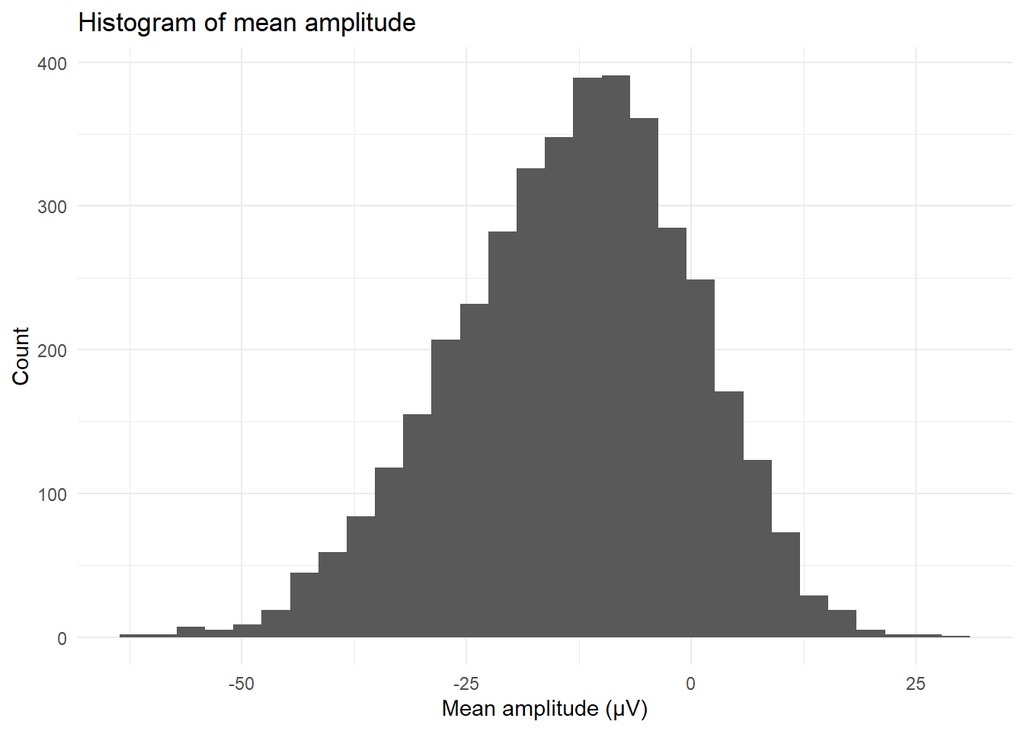

```r
# Distribution of mean amplitude
ggplot(data = sim_data, aes(x = MeanAmp)) +
  geom_histogram() +
  theme_minimal() +
  labs(x = "Mean amplitude (µV)", y = "Count",
       title = "Histogram of mean amplitude")
```

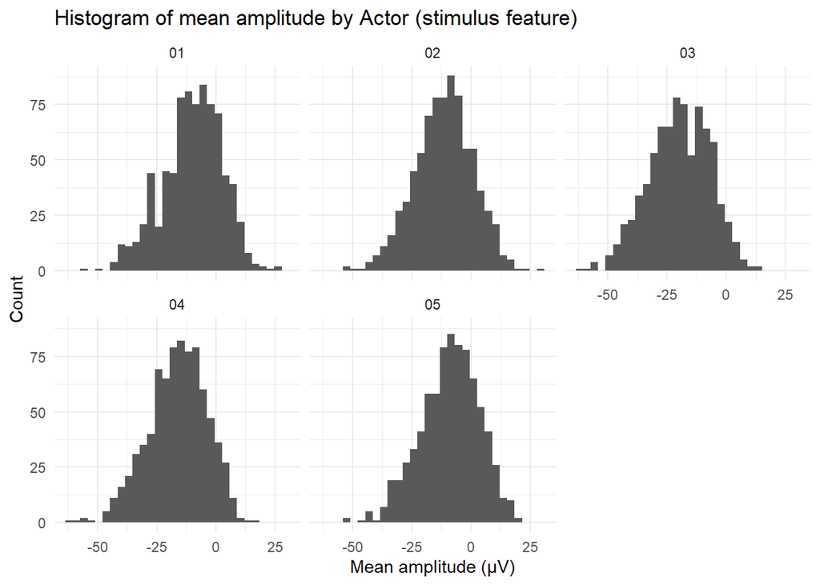

```r
# Distribution of mean amplitude (by actor)
ggplot(data = sim_data, aes(x = MeanAmp)) +
  geom_histogram() +
  theme_minimal() +
  labs(x = "Mean amplitude (µV)", y = "Count",
       title = "Histogram of mean amplitude by Actor (stimulus feature)") +
  facet_wrap(~ActorID) # +facet_wrap(~ActorID+Emotion)
```

```r
# Summary statistics by actor/stimulus feature
sim_data %>%
  group_by(ActorID) %>%
  summarize(mean = mean(MeanAmp),
            sd = sd(MeanAmp),
            median = median(MeanAmp),
            min = min(MeanAmp),
            max = max(MeanAmp))
```

```
## # A tibble: 5 × 6
##   ActorID   mean    sd median   min   max
##   <chr>    <dbl> <dbl>  <dbl> <dbl> <dbl>
## 1 01       -9.86  12.6  -8.95 -57.2  26.1
## 2 02      -11.4   12.3 -10.7  -52.8  29.4
## 3 03      -19.8   12.8 -19.5  -62.0  13.8
## 4 04      -16.1   12.3 -15.1  -60.9  15.8
## 5 05       -8.94  12.4  -8.29 -53.4  20.4
```

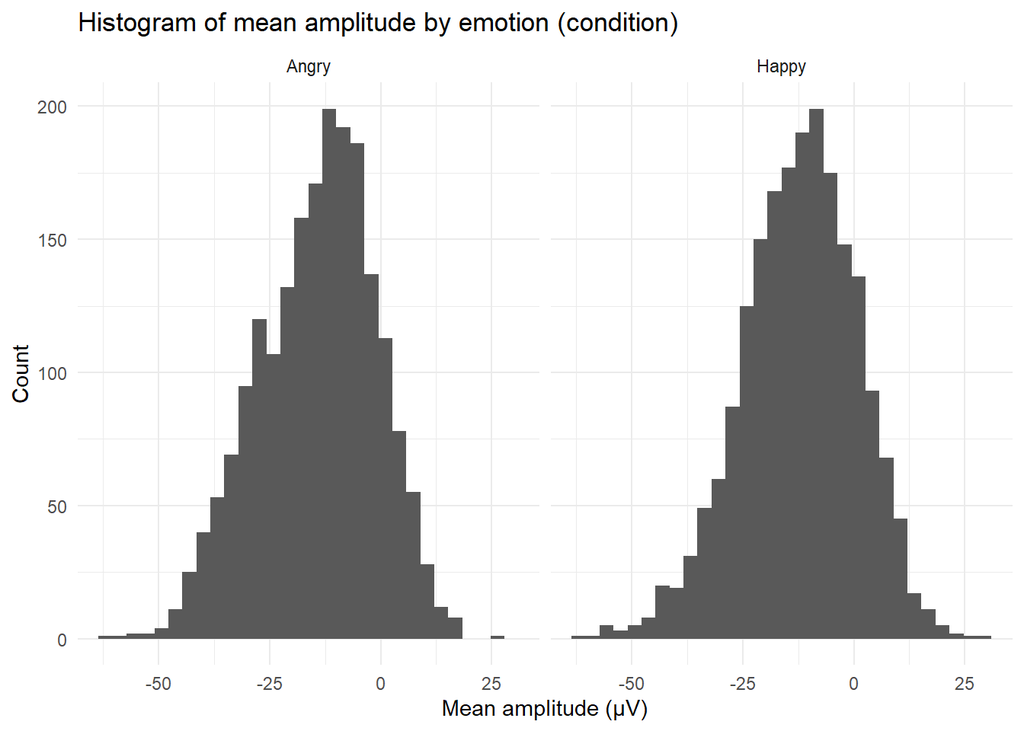

```r
# Distribution of mean amplitude (by emotion)
ggplot(data = sim_data, aes(x = MeanAmp)) +
  geom_histogram() +
  theme_minimal() +
  labs(x = "Mean amplitude (µV)", y = "Count",
       title = "Histogram of mean amplitude by emotion (condition)") +
  facet_wrap(~Emotion)
```

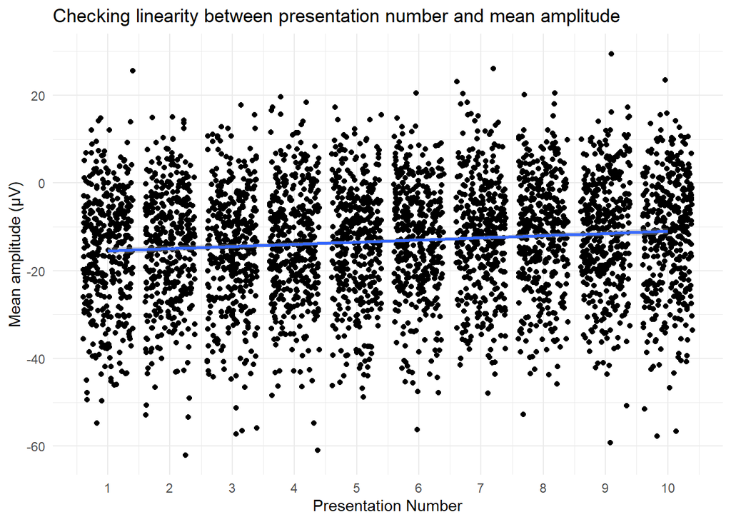

```r
# Linearity of predictors
ggplot(data = sim_data, aes(x = PresentNum, y = MeanAmp)) +
  geom_jitter() +
  geom_smooth(formula = y ~ x, method = "lm") +
  theme_minimal() +
  scale_x_continuous(breaks = seq(0, 10, by = 1)) +
  labs(x = "Presentation Number", y = "Mean amplitude (µV)",
       title = "Checking linearity between presentation number and mean amplitude") # + facet_wrap(~Emotion+Actor)
```

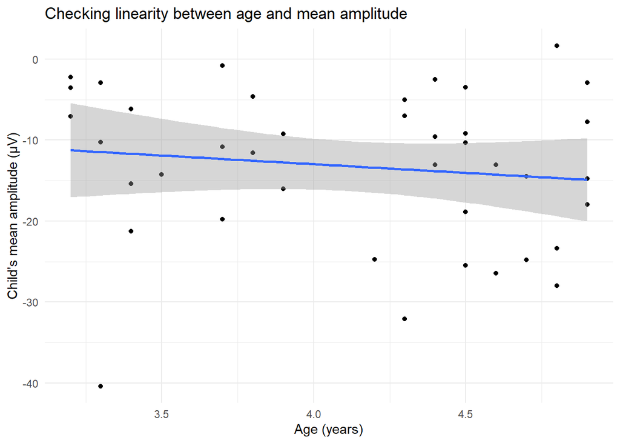

```r
# Linearity of age (a participant-level predictor: plot one mean per child)
sim_data %>%
  group_by(SubjectID, AgeYears) %>%
  summarize(MeanAmp = mean(MeanAmp), .groups = "drop") %>%
  ggplot(aes(x = AgeYears, y = MeanAmp)) +
  geom_point() +
  geom_smooth(formula = y ~ x, method = "lm") +
  theme_minimal() +
  labs(x = "Age (years)", y = "Child's mean amplitude (µV)",
       title = "Checking linearity between age and mean amplitude")
```

# 4 Fitting an LME

We’ll follow 9 steps to building an LME:

## 4.1 Step 1: Define the research question(s)

1. Is there a difference in NC mean amplitude elicited by Happy vs. Angry faces?
2. Does the magnitude of the NC emotion difference change with age (3 to 5 years)?

## 4.2 Step 2: List all relevant variables

- SubjectID
- Stimulus type (ActorID)
- Trial presentation number (PresentNum)
- Emotion condition (Emotion)
- Age in years (AgeYears)

## 4.3 Step 3: Draw the study design schematic

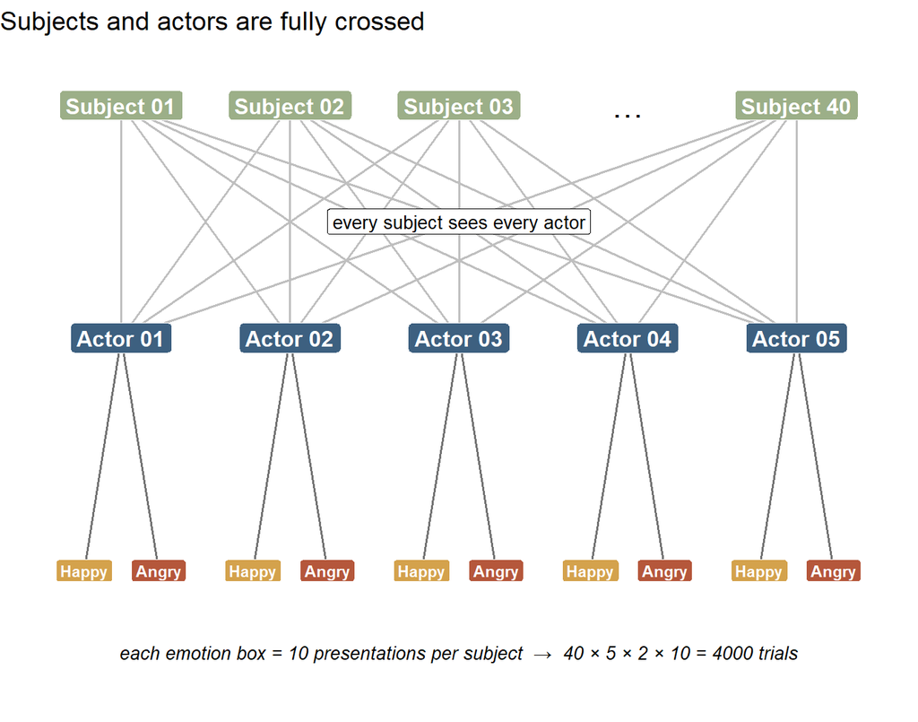

```r
subj_nodes  <- tibble(label = c("Subject 01", "Subject 02", "Subject 03", "…",
                                paste("Subject", n_subjects)),
                      x = 1:5, y = 2)
actor_nodes <- tibble(label = paste("Actor", sprintf("%02d", 1:n_actors)),
                      x = seq(1, 5, length.out = n_actors), y = 1)
emotion_nodes <- expand_grid(actor_x = actor_nodes$x,
                             Emotion = emotion_labels) %>%
  mutate(x = actor_x + if_else(Emotion == "Happy", -0.22, 0.22), y = 0)
edges <- expand_grid(x = subj_nodes$x[subj_nodes$label != "…"],
                     xend = actor_nodes$x)

ggplot() +
  geom_segment(data = edges, aes(x = x, xend = xend, y = 2, yend = 1),
               colour = "grey75") +
  geom_segment(data = emotion_nodes, aes(x = actor_x, xend = x, y = 1, yend = 0),
               colour = "grey45") +
  geom_label(data = filter(subj_nodes, label != "…"), aes(x, y, label = label),
             fill = "#9CAF88", colour = "white", fontface = "bold") +
  geom_text(data = filter(subj_nodes, label == "…"), aes(x, y, label = label),
            size = 6) +
  geom_label(data = actor_nodes, aes(x, y, label = label),
             fill = "#3D6080", colour = "white", fontface = "bold") +
  geom_label(data = emotion_nodes, aes(x, y, label = Emotion, fill = Emotion),
             colour = "white", fontface = "bold", size = 3) +
  scale_fill_manual(values = c(Happy = "#D4A24C", Angry = "#B5573B"),
                    guide = "none") +
  annotate("label", x = 3, y = 1.5, fill = "white", size = 3.5,
           label = "every subject sees every actor") +
  annotate("text", x = 3, y = -0.35, size = 3.5, fontface = "italic",
           label = paste0("each emotion box = ", n_presentations,
                          " presentations per subject  →  ", n_subjects, " × ",
                          n_actors, " × 2 × ", n_presentations, " = ",
                          n_subjects * n_actors * 2 * n_presentations,
                          " trials")) +
  labs(title = "Subjects and actors are fully crossed") +
  scale_x_continuous(expand = expansion(add = 0.5)) +
  scale_y_continuous(expand = expansion(add = 0.3)) +
  theme_void(base_size = 12)
```

## 4.4 Step 4: Categorize variables by type (categorical, numeric) & level (trial vs. subject)

- SubjectID: factor/categorical, participant
- ActorID: factor/categorical, trial
- PresentNum: numeric/continuous, trial
- Emotion: factor/categorical, trial
- AgeYears: numeric/continuous, participant

## 4.5 Step 5: Assign fixed and random effects

### 4.5.1 Fixed effects

- Emotion
- Presentation Number
- Age
- Interaction between Emotion x age (research question 2)
- Interaction between Emotion x presentation number? We don’t have a hypothesis about it, but habituation could differ by emotion, so we will include it as a covariate

### 4.5.2 Random effects syntax

- Random intercept only: `(1 | grouping)`, e.g., `(1 | SubjectID)` gives each participant their own baseline mean amplitude
- Random intercept + random slope: `(predictor | grouping)` or `(1 + predictor | grouping)`, e.g., `(1 + Emotion | SubjectID)` gives each participant their own baseline *and* their own emotion effect
  - The predictor (left of `|`) must vary *within* each level of the grouping factor (right of `|`)
- Uncorrelated intercept + slope: `(1 + predictor || grouping)`, which estimates the same variances but fixes the intercept–slope correlation at 0 (only works as intended with numeric predictors, it’s uncommon to use this unless there’s good theoretical evidence)

### 4.5.3 Possible random effects in our design

*SubjectID*

- `(1 | SubjectID)`: Do some participants have higher or lower mean amplitudes on average?
- `(1 + Emotion | SubjectID)`: Does the effect of emotion (Happy vs. Angry) differ across participants?
- `(1 + PresentNum | SubjectID)`: Does habituation (change in amplitude across presentations) differ across participants?
- `(1 + Emotion * PresentNum | SubjectID)`: Does the change in the emotion effect across presentations differ across participants?
- **No** `(1 + Age | SubjectID)`: each child has only one age, so age doesn’t vary *within* a participant and an age slope by participant can’t be estimated. Age is a fixed effect (a measured characteristic of each child), not a random effect.

*ActorID*

- `(1 | ActorID)`: Do some actors’ faces produce larger or smaller mean amplitudes overall, across both emotions?
- `(1 + Emotion | ActorID)`: Does the effect of emotion differ across actors (e.g., some actors pose a more intense angry expression)?
- `(1 + PresentNum | ActorID)`: Does habituation differ across actors (e.g., amplitude drops faster for some faces)?
- `(1 + Emotion * PresentNum | ActorID)`: Does the change in the emotion effect across presentations differ across actors?
- `(1 + Age | ActorID)` and `(1 + Emotion * Age | ActorID)`: Does the age effect (or the way the emotion effect changes with age) differ across actors? Age varies within actors (each actor is seen by children of all ages), so these slopes *could* be estimated. But we have no theoretical reason to expect that some faces show larger age effects than others, so **we decided not to include them** in the maximal model. Decide this before you fit the model.

*SubjectID × ActorID (optional)*

- `(1 | SubjectID:ActorID)`: Do particular participants respond differently to particular actors, beyond the separate participant and actor effects?

**Random slopes we’d prioritize:** a SubjectID × Emotion slope (Does the effect of emotion differ across participants?) and an ActorID × Emotion slope (Does the effect of emotion differ across actors?). These seem like the two most probable random effects we could observe and we also want to prioritize capturing variance in emotion condition.

## 4.6 Step 6: Consider data transformations & center predictors

*Data transformations (e.g., nonlinear effects):* There wasn’t evidence for nonlinear effects in our exploratory data visualization, so we would fit a linear effect of presentation number.

*Centering presentation number:* - Without an interaction (e.g., MeanAmp ~ Emotion + PresentNum + (1|SubjectID)), centering only effects the intercept. - With an interaction (e.g., MeanAmp ~ Emotion*PresentNum + (1|SubjectID)), uncentered presentation number will give predicted amplitude for the reference emotion at trial 0 (a trial that doesn’t exist in our numbering scheme, but you could re-number the trial numbers to create a real trial) at 0. - Centering presentation number will give predicted amplitude for the reference emotion at the average trial.

*Centering age:* - Age is a participant-level predictor, so we could consider **grand-mean centering** (`Age_gmc` = age minus the sample’s mean age). The intercept is then the predicted amplitude for a child of average age, instead of a child age 0.

*Naming conventions:* we label each centered variable by how it was centered: `_gmc` for grand-mean centered (e.g., `Age_gmc`, `PresentNum_gmc`) and `_cwc` for centered within cluster (e.g., `PresentNum_cwc`, later in the tutorial).

*Coding Emotion:* for now, we’ll use R’s default **dummy coding**: Angry = 0 and Happy = 1, so Angry is the **reference group**. We’ll come back to effects coding after we’ve fit and interpreted the final model (see “Circling back: dummy vs. effects coding”).

```r
sim_data <- sim_data %>%
  mutate(PresentNum_gmc = PresentNum - mean(PresentNum),
         PresentNum_True0 = (PresentNum - 1))

# Grand-mean center age using one value per child (the mean of the children's ages)
mean_age <- mean(distinct(sim_data, SubjectID, AgeYears)$AgeYears)
sim_data <- sim_data %>%
  mutate(Age_gmc = AgeYears - mean_age)

sim_data %>%
  select(SubjectID, Emotion, MeanAmp, PresentNum, PresentNum_gmc, PresentNum_True0,
         AgeYears, Age_gmc)
```

```
## # A tibble: 4,000 × 8
##    SubjectID Emotion MeanAmp PresentNum PresentNum_gmc PresentNum_True0 AgeYears Age_gmc
##    <chr>     <chr>     <dbl>      <int>          <dbl>            <dbl>    <dbl>   <dbl>
##  1 01        Happy   -12.7            1           -4.5                0      3.9  -0.228
##  2 01        Happy    -5.76           2           -3.5                1      3.9  -0.228
##  3 01        Happy    -6.38           3           -2.5                2      3.9  -0.228
##  4 01        Happy    -4.01           4           -1.5                3      3.9  -0.228
##  5 01        Happy    -4.32           5           -0.5                4      3.9  -0.228
##  6 01        Happy     6.29           6            0.5                5      3.9  -0.228
##  7 01        Happy    -3.08           7            1.5                6      3.9  -0.228
##  8 01        Happy     0.791          8            2.5                7      3.9  -0.228
##  9 01        Happy    -2.30           9            3.5                8      3.9  -0.228
## 10 01        Happy   -10.7           10            4.5                9      3.9  -0.228
## # ℹ 3,990 more rows
```

## 4.7 Step 7: Fit the maximal model and simplify until convergence is reached

We’ll start from our theoretically-driven maximal model and simplify it **one random effect at a time**, using a “leave-one-out” approach: remove one random effect, refit, and check the fit. If that doesn’t fix the problem, put it back and remove the matching random effect for the other grouping factor instead. If neither version converges without a singular fit, remove both and move on to the next type of random effect. We work through them in this order:

1. **Interaction slopes first (Step 7b):** they’re the least plausible and the hardest to estimate.
2. **Then main-effect slopes (Step 7c):** presentation number (habituation) before emotion, because emotion is the effect we care most about. Within each pair, we try the ActorID slope first: with only 5 actors, there’s the least information to estimate how actors differ.
3. **Until we reach random intercepts only (Step 7d),** or stop earlier as soon as a model converges without a singular fit.

At each step, we check:

- **Estimation warnings:** Is the fit singular or non-converging (`isSingular()`, `check_convergence()`)? This tells us *that* the model is too complex, but not *which* term is the problem.
- **Variance components:** In `VarCorr()` output, look for random-effect SDs near zero and correlations near ±1.

We’ll use a helper function so each model prints the same diagnostics:

```r
check_fit <- function(fit) {
  cat("Singular fit:", isSingular(fit), "\n\n")
  print(VarCorr(fit), comp = "Std.Dev.")  # random-effect SDs and correlations
}
```

### 4.7.1 Step 7a: Fit the maximal model

```r
# Maximal model following Barr et al. (2013)
fit_max <- lmer(MeanAmp ~ Emotion * PresentNum_True0 + Emotion * Age_gmc +
                  (1 + Emotion * PresentNum_True0 | SubjectID) +  # children differ in amplitude, emotion effect, habituation,
                                                                  # and how the emotion effect changes over presentations
                  (1 + Emotion * PresentNum_True0 | ActorID),     # actors differ in amplitude, emotion effect, habituation,
                                                                  # and how the emotion effect changes over presentations
                data = sim_data)

check_fit(fit_max)
```

```
## Singular fit: TRUE
##
##  Groups    Name                          Std.Dev. Corr
##  SubjectID (Intercept)                   9.502915
##            EmotionHappy                  2.149342  0.088
##            PresentNum_True0              0.117566  0.191  0.995
##            EmotionHappy:PresentNum_True0 0.369148 -0.194 -0.994 -1.000
##  ActorID   (Intercept)                   4.461816
##            EmotionHappy                  0.254161 -0.230
##            PresentNum_True0              0.030179  0.093  0.948
##            EmotionHappy:PresentNum_True0 0.075909  0.901 -0.629 -0.348
##  Residual                                7.968956
```

A singular fit means the model estimated a random-effect variance at zero or a correlation at ±1.

What the variance components tell us:

- **ActorID:** the slope SDs are close to zero, and several correlations are near ±1.
- **SubjectID:** the slopes are correlated with each other at about ±.99 or higher, so some terms are redundant with each other.

### 4.7.2 Leave-one-out approach

Here’s every model we would fit along the way to reaching a model that converges and doesn’t have a singular fit. Some of these are in code chunks below to illustrate what the output looks like.

**Round 1: interaction slopes** (starting from the maximal model, Step 7a)

- Remove the by-actor interaction slope: `(1 + Emotion * PresentNum_True0 | SubjectID) + (1 + Emotion + PresentNum_True0 | ActorID)` → still singular (shown below as `fit_7b1`).
- Put it back and remove the by-participant interaction slope instead: `(1 + Emotion + PresentNum_True0 | SubjectID) + (1 + Emotion * PresentNum_True0 | ActorID)` → still singular, and it also fails to converge (not shown).
- Neither works, so remove both: `(1 + Emotion + PresentNum_True0 | SubjectID) + (1 + Emotion + PresentNum_True0 | ActorID)` → still singular (shown below as `fit_7b2`).

**Round 2: presentation-number slopes** (habituation)

- Remove the by-actor slope (do actors differ in how fast children habituate to them?): `(1 + Emotion + PresentNum_True0 | SubjectID) + (1 + Emotion | ActorID)` → still singular (shown below as `fit_7c1`).
- Put it back and remove the by-participant slope (do children habituate at different rates?): `(1 + Emotion | SubjectID) + (1 + Emotion + PresentNum_True0 | ActorID)` → still singular (not shown).
- Neither works, so remove both: `(1 + Emotion | SubjectID) + (1 + Emotion | ActorID)` → still singular (shown below as `fit_7c2`).

**Round 3: emotion slopes** (the effect we care most about, so these go last)

- Remove the by-actor slope (do actors pose emotions with different intensity?): `(1 + Emotion | SubjectID) + (1 | ActorID)` → still singular: the by-participant emotion slope is tiny, with a correlation of −1 with the intercept (shown below as `fit_7c3`).
- Put it back and remove the by-participant slope (do children differ in their emotion effect?): `(1 | SubjectID) + (1 + Emotion | ActorID)` → still singular: the by-actor emotion slope has a correlation of +1 with the intercept (not shown).
- Neither works, so remove both: `(1 | SubjectID) + (1 | ActorID)` → converges and isn’t singular: this is our final random-effects structure (Step 7d, `fit_int1`).

### 4.7.3 Step 7b: Remove the interaction slopes

Round 1, first try: remove the ActorID interaction slope.

```r
fit_7b1 <- lmer(MeanAmp ~ Emotion * PresentNum_True0 + Emotion * Age_gmc +
                  (1 + Emotion * PresentNum_True0 | SubjectID) +
                  (1 + Emotion + PresentNum_True0 | ActorID),
                data = sim_data)

check_fit(fit_7b1)
```

```
## Singular fit: TRUE
##
##  Groups    Name                          Std.Dev. Corr
##  SubjectID (Intercept)                   9.505503
##            EmotionHappy                  2.147683  0.090
##            PresentNum_True0              0.117373  0.194  0.994
##            EmotionHappy:PresentNum_True0 0.368827 -0.197 -0.994 -1.000
##  ActorID   (Intercept)                   4.315299
##            EmotionHappy                  0.253278 1.000
##            PresentNum_True0              0.037678 1.000  1.000
##  Residual                                7.969711
```

Still singular. Removing only the SubjectID interaction slope instead is also singular (not shown), so we remove both:

```r
fit_7b2 <- lmer(MeanAmp ~ Emotion * PresentNum_True0 + Emotion * Age_gmc +
                  (1 + Emotion + PresentNum_True0 | SubjectID) +
                  (1 + Emotion + PresentNum_True0 | ActorID),
                data = sim_data)

check_fit(fit_7b2)
```

```
## Singular fit: TRUE
##
##  Groups    Name             Std.Dev. Corr
##  SubjectID (Intercept)      9.698156
##            EmotionHappy     0.094795 -0.971
##            PresentNum_True0 0.019336 -0.970  0.883
##  ActorID   (Intercept)      4.307154
##            EmotionHappy     0.252323 1.000
##            PresentNum_True0 0.037511 1.000  1.000
##  Residual                   7.993325
```

Still singular, so we move on to the main-effect slopes.

### 4.7.4 Step 7c: Remove the main-effect slopes

Round 2, first try: remove the ActorID presentation-number slope (different habituation for different actors).

```r
fit_7c1 <- lmer(MeanAmp ~ Emotion * PresentNum_True0 + Emotion * Age_gmc +
                  (1 + Emotion + PresentNum_True0 | SubjectID) +
                  (1 + Emotion | ActorID),
                data = sim_data)

check_fit(fit_7c1)
```

```
## Singular fit: TRUE
##
##  Groups    Name             Std.Dev. Corr
##  SubjectID (Intercept)      9.696826
##            EmotionHappy     0.092001 -1.000
##            PresentNum_True0 0.018626 -1.000  1.000
##  ActorID   (Intercept)      4.482128
##            EmotionHappy     0.253246 1.000
##  Residual                   7.993931
```

Still singular. Removing only the SubjectID presentation-number slope instead is also singular (not shown), so we remove both presentation-number slopes:

```r
fit_7c2 <- lmer(MeanAmp ~ Emotion * PresentNum_True0 + Emotion * Age_gmc +
                  (1 + Emotion | SubjectID) +
                  (1 + Emotion | ActorID),
                data = sim_data)

check_fit(fit_7c2)
```

```
## Singular fit: TRUE
##
##  Groups    Name         Std.Dev. Corr
##  SubjectID (Intercept)  9.614502
##            EmotionHappy 0.091745 -1.000
##  ActorID   (Intercept)  4.483994
##            EmotionHappy 0.253267 1.000
##  Residual               7.994095
```

Still singular. Round 3, first try: remove the ActorID emotion slope (different actors express the emotions with different intensity).

```r
fit_7c3 <- lmer(MeanAmp ~ Emotion * PresentNum_True0 + Emotion * Age_gmc +
                  (1 + Emotion | SubjectID) +
                  (1 | ActorID),
                data = sim_data)

check_fit(fit_7c3)
```

```
## Singular fit: TRUE
##
##  Groups    Name         Std.Dev. Corr
##  SubjectID (Intercept)  9.614051
##            EmotionHappy 0.091779 -1.000
##  ActorID   (Intercept)  4.610797
##  Residual               7.994913
```

Still singular: the by-participant emotion slope SD is only 0.09 µV (next to an intercept SD of about 10 µV), and its correlation with the intercept is at ±1. Removing only the by-participant emotion slope instead is also singular (not shown), so we remove both emotion slopes.

### 4.7.5 Step 7d: Random intercepts only

```r
fit_int1 <- lmer(MeanAmp ~ Emotion * PresentNum_True0 + Emotion * Age_gmc +
                   (1 | SubjectID) + (1 | ActorID),
                 data = sim_data)

check_fit(fit_int1)
```

```
## Singular fit: FALSE
##
##  Groups    Name        Std.Dev.
##  SubjectID (Intercept) 9.5682
##  ActorID   (Intercept) 4.6108
##  Residual              7.9950
```

```r
performance::check_convergence(fit_int1)
```

```
## [1] TRUE
## attr(,"gradient")
## [1] 3.086323e-06
```

This model converges and isn’t singular, so this is our **final random-effects structure**. That matches our simulation: we only simulated random intercepts, so every slope’s true SD is 0. Next we look at the fixed effects (Step 7e).

### 4.7.6 Step 7e: Looking more at our fixed effects interactions (optional)

Once we’ve reached the maximal random effects structure that converges, we’re going to look more at our fixed effects to demonstrate some possible decisions we may have made (e.g., about centering). We might also pre-register some model simplification steps about our fixed effects (e.g., if interactions don’t significantly improve model fit, we will remove interactions to fit a more parisimonious model). Or we might compare competing models (e.g., we might fit two models that each have a different behavioral predictor that is correlated, e.g., including either income or education level attained, see example in Mon et al., 2024).

The two interactions in our model:

- **Emotion × Age is research question 2, so we keep it** whatever the test shows. If a hypothesized interaction isn’t significant, report it as non-significant (estimate, 95% CI, *p*). Dropping it because it wasn’t significant is a data-driven choice that makes the remaining *p*-values look more certain than they are.
- **Emotion × Presentation number is a covariate.** We might pre-register that if this interaction doesn’t improve model fit (likelihood-ratio test, *p* > .05), we will omit it for a simpler model.

Nested models (models in which one is a simplified version of another) can be tested using the lme4::anova function. anova(fit_no_ep, fit_int1) runs a likelihood-ratio test (LRT): does the bigger model fit the data significantly better than the smaller one? It reports each model’s AIC, BIC, log-likelihood and deviance, then a χ² test. The χ² is the difference in deviance, and its df is the number of extra parameters (here 1, for the interaction). A significant p means the extra term improves the fit. Because the models differ in their fixed effects, anova() automatically refits both with maximum likelihood (ML) instead of REML before comparing them (refit = TRUE, the default). To compare models that differ only in their random effects, add refit = FALSE to keep REML.

```r
# Without the Emotion x Presentation number interaction (same random effects)
fit_no_ep <- lmer(MeanAmp ~ Emotion * Age_gmc + PresentNum_True0 +
                    (1 | SubjectID) + (1 | ActorID),
                  data = sim_data)
anova(fit_no_ep, fit_int1)   # refits both with ML (REML = FALSE)
```

```
## Data: sim_data
## Models:
## fit_no_ep: MeanAmp ~ Emotion * Age_gmc + PresentNum_True0 + (1 | SubjectID) + (1 | ActorID)
## fit_int1: MeanAmp ~ Emotion * PresentNum_True0 + Emotion * Age_gmc + (1 | SubjectID) + (1 | ActorID)
##           npar   AIC   BIC logLik deviance  Chisq Df Pr(>Chisq)
## fit_no_ep    8 28214 28265 -14099    28198
## fit_int1     9 28216 28273 -14099    28198 0.1697  1     0.6804
```

The Emotion × Presentation number interaction doesn’t improve the fit (*p* = 0.68), so following our rule, we will remove it. Emotion × Age stays in because it’s one of our research questions.

Here’s our **final model**, fit with REML (the default):

```r
fit_final <- lmer(MeanAmp ~ Emotion * Age_gmc + PresentNum_True0 +
                    (1 | SubjectID) + (1 | ActorID),
                  data = sim_data)

summary(fit_final)
```

```
## Linear mixed model fit by REML. t-tests use Satterthwaite's method ['lmerModLmerTest']
## Formula: MeanAmp ~ Emotion * Age_gmc + PresentNum_True0 + (1 | SubjectID) +      (1 | ActorID)
##    Data: sim_data
##
## REML criterion at convergence: 28196.1
##
## Scaled residuals:
##     Min      1Q  Median      3Q     Max
## -3.4460 -0.6864  0.0108  0.6586  3.5025
##
## Random effects:
##  Groups    Name        Variance Std.Dev.
##  SubjectID (Intercept) 91.55    9.568
##  ActorID   (Intercept) 21.26    4.611
##  Residual              63.91    7.994
## Number of obs: 4000, groups:  SubjectID, 40; ActorID, 5
##
## Fixed effects:
##                        Estimate Std. Error         df t value Pr(>|t|)
## (Intercept)           -16.46275    2.57142    9.31259  -6.402 0.000107 ***
## EmotionHappy            1.99846    0.25280 3953.00028   7.905 3.44e-15 ***
## Age_gmc                -2.87091    2.63796   38.52833  -1.088 0.283220
## PresentNum_True0        0.49528    0.04401 3953.00028  11.255  < 2e-16 ***
## EmotionHappy:Age_gmc    1.45851    0.43775 3953.00028   3.332 0.000871 ***
## ---
## Signif. codes:  0 '***' 0.001 '**' 0.01 '*' 0.05 '.' 0.1 ' ' 1
##
## Correlation of Fixed Effects:
##             (Intr) EmtnHp Ag_gmc PrN_T0
## EmotionHppy -0.049
## Age_gmc      0.000  0.000
## PrsntNm_Tr0 -0.077  0.000  0.000
## EmtnHppy:A_  0.000  0.000 -0.083  0.000
```

```r
tab_model(fit_final)
```

|  | Mean Amp |  |  |
| --- | --- | --- | --- |
| Predictors | Estimates | CI | p |
| (Intercept) | -16.46 | -21.50 – -11.42 | **<0.001** |
| Emotion [Happy] | 2.00 | 1.50 – 2.49 | **<0.001** |
| Age gmc | -2.87 | -8.04 – 2.30 | 0.277 |
| PresentNum True0 | 0.50 | 0.41 – 0.58 | **<0.001** |
| Emotion [Happy] × Age gmc | 1.46 | 0.60 – 2.32 | **0.001** |
| Random Effects |  |  |  |
| σ<sup>2</sup> | 63.91 |  |  |
| τ<sub>00</sub> <sub>SubjectID</sub> | 91.55 |  |  |
| τ<sub>00</sub> <sub>ActorID</sub> | 21.26 |  |  |
| ICC | 0.64 |  |  |
| N <sub>SubjectID</sub> | 40 |  |  |
| N <sub>ActorID</sub> | 5 |  |  |
| Observations | 4000 |  |  |
| Marginal R<sup>2</sup> / Conditional R<sup>2</sup> | 0.026 / 0.648 |  |  |

### 4.7.7 Describing the simplification in your methods

In a methods section, you might write: *“We began with the maximal random-effects structure (Barr et al., 2013), without by-actor slopes for age, which we had no theoretical reason to expect. We simplified it one term at a time until the model converged without a singular fit, removing interaction slopes first and then main-effect slopes, starting with the by-actor slopes and keeping the by-participant emotion slope until last (Bates et al., 2015; Matuschek et al., 2017). We then tested the emotion × presentation number interaction, which we had pre-specified as a covariate, with a likelihood-ratio test, and removed it because it did not improve model fit (χ²(1) = 0.17, *p* = .68). The final model included random intercepts for participants and actors, and fixed effects of emotion, presentation number, age (grand-mean centered), and the emotion × age interaction.”*

## 4.8 Step 8: Check model assumptions

The assumptions of an LME are similar to those of linear regression (Heise et al., 2022, Section 2.2):

1. **Linearity:** continuous predictors are linearly related to the outcome.
2. **Normal distribution of residuals:** the residuals follow a normal distribution and aren’t skewed.
3. **Homoscedasticity (homogeneity of variance):** the residuals have similar spread across groups (e.g., emotion conditions) and across the range of predicted values.

Unlike linear regression, LME does **not** assume that data points are independent, because the random effects model the dependence among trials from the same participant or actor. LME does add one assumption of its own: the random effects (e.g., each participant’s intercept) are also assumed to be normally distributed.

We check all of these at once with `check_model()` from the performance package (Lüdecke et al., 2021), which draws one diagnostic plot per assumption. It needs the **see** package installed to draw the plots.

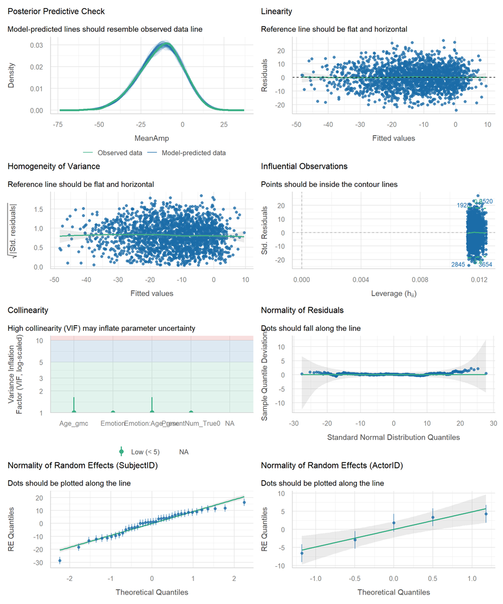

```r
check_model(fit_final)
```

**Why plots instead of tests?** With 4000 trials, formal tests (e.g., Shapiro-Wilk for normality or a test for heteroscedasticity) can be significant even when there are only small deviations from the assumption. Some researchers recommend Shapiro-Wilk for samples up to 5,000 but other researchers suggest that Shapiro-Wilk is too sensitive even lower (e.g., at 4,000 observations). Beyond 4,000-5,000 observations/total trials you should use visual inspection.

### 4.8.1 Reporting

You might write: *“Model assumptions (linearity, homogeneity of variance, normality of the residuals and random effects, collinearity, and influential observations) were checked by visual inspection of diagnostic plots (`check_model()` in the performance package; Lüdecke et al., 2021).”*

## 4.9 Step 9: Interpret and visualize results

### 4.9.1 Interpreting the model output

Let’s start with the model output:

```r
# There's the default R output from our model
summary(fit_final)
```

```
## Linear mixed model fit by REML. t-tests use Satterthwaite's method ['lmerModLmerTest']
## Formula: MeanAmp ~ Emotion * Age_gmc + PresentNum_True0 + (1 | SubjectID) +      (1 | ActorID)
##    Data: sim_data
##
## REML criterion at convergence: 28196.1
##
## Scaled residuals:
##     Min      1Q  Median      3Q     Max
## -3.4460 -0.6864  0.0108  0.6586  3.5025
##
## Random effects:
##  Groups    Name        Variance Std.Dev.
##  SubjectID (Intercept) 91.55    9.568
##  ActorID   (Intercept) 21.26    4.611
##  Residual              63.91    7.994
## Number of obs: 4000, groups:  SubjectID, 40; ActorID, 5
##
## Fixed effects:
##                        Estimate Std. Error         df t value Pr(>|t|)
## (Intercept)           -16.46275    2.57142    9.31259  -6.402 0.000107 ***
## EmotionHappy            1.99846    0.25280 3953.00028   7.905 3.44e-15 ***
## Age_gmc                -2.87091    2.63796   38.52833  -1.088 0.283220
## PresentNum_True0        0.49528    0.04401 3953.00028  11.255  < 2e-16 ***
## EmotionHappy:Age_gmc    1.45851    0.43775 3953.00028   3.332 0.000871 ***
## ---
## Signif. codes:  0 '***' 0.001 '**' 0.01 '*' 0.05 '.' 0.1 ' ' 1
##
## Correlation of Fixed Effects:
##             (Intr) EmtnHp Ag_gmc PrN_T0
## EmotionHppy -0.049
## Age_gmc      0.000  0.000
## PrsntNm_Tr0 -0.077  0.000  0.000
## EmtnHppy:A_  0.000  0.000 -0.083  0.000
```

```r
# Here's output from the sjPlot package
tab_model(fit_final)
```

|  | Mean Amp |  |  |
| --- | --- | --- | --- |
| Predictors | Estimates | CI | p |
| (Intercept) | -16.46 | -21.50 – -11.42 | **<0.001** |
| Emotion [Happy] | 2.00 | 1.50 – 2.49 | **<0.001** |
| Age gmc | -2.87 | -8.04 – 2.30 | 0.277 |
| PresentNum True0 | 0.50 | 0.41 – 0.58 | **<0.001** |
| Emotion [Happy] × Age gmc | 1.46 | 0.60 – 2.32 | **0.001** |
| Random Effects |  |  |  |
| σ<sup>2</sup> | 63.91 |  |  |
| τ<sub>00</sub> <sub>SubjectID</sub> | 91.55 |  |  |
| τ<sub>00</sub> <sub>ActorID</sub> | 21.26 |  |  |
| ICC | 0.64 |  |  |
| N <sub>SubjectID</sub> | 40 |  |  |
| N <sub>ActorID</sub> | 5 |  |  |
| Observations | 4000 |  |  |
| Marginal R<sup>2</sup> / Conditional R<sup>2</sup> | 0.026 / 0.648 |  |  |

### 4.9.2 Fixed effects

`Emotion` is a character variable, so R uses alphabetical order and **Angry is the reference level**. `EmotionHappy` is therefore the Happy − Angry difference. Because our model includes an Emotion × Age interaction, the `Emotion` and `Age_gmc` coefficients are *simple effects*: each is the effect when the predictor it interacts with is 0. So the emotion effect is for a child of average age (`Age_gmc` = 0, i.e., 4.1 years), and the age effect is for **Angry** faces. Presentation number doesn’t interact with anything, so its slope applies to both emotions.

```r
b_raw <- fixef(fit_final)
```

- **(Intercept) = -16.46 µV:** predicted mean amplitude for **Angry** faces on the **first presentation** (`PresentNum_True0` = 0), for a child of average age.
- **EmotionHappy = 2 µV:** Happy faces elicit a mean amplitude 2 µV more positive than Angry faces **for a child of average age** (simulated: 2 µV at age 4).
- **PresentNum_True0 = 0.5 µV:** for both emotions, mean amplitude becomes 0.5 µV more positive with each additional presentation (habituation; simulated: 0.5 µV).
- **Age_gmc = -2.87 µV:** for **Angry** faces, the predicted change in mean amplitude for each additional year of age (simulated: -2.75 µV per year for Angry faces; p = 0.283). Look at its df (≈ 39) and SE: age is a participant-level predictor, so it’s tested against differences *between children* (SD ≈ 9.6 µV) with only 40 children, not against the 4,000 trials. A 2-to-3 µV-per-year effect over a 2-year age range is small next to that, so the estimate can land far from the simulated value. Participant-level effects need enough *participants*; more trials don’t help.
- **EmotionHappy:Age_gmc = 1.46 µV:** how much the age effect differs for Happy vs. Angry faces (Happy age effect = -1.41 µV per year). Equivalently, how much the Happy − Angry difference grows per year of age (simulated: 1.5 µV; p < .001). Unlike `Age_gmc`, this is tested against trial-level variability (look at its df), because the emotion effect is measured within each child.

### 4.9.3 Visualizing the results

I prefer plotting the LME model’s **estimated marginal means** (EMMs) for the fixed effects of interest, rather than raw averages because when we report our models we’re reporting the model estimates (not the raw averages). EMMs are the model’s predicted mean amplitude for each condition, averaged over (or set at the mean of) the other predictors, so they use every trial and account for the random effects. When it’s possible, it’s nice to show subject averages or trial-level variability so that readers get a sense of the means and spread of the data. We’ll make three plots:

1. EMMs across repeated presentations
2. EMMs for each emotion
3. EMMs across age, our participant-level predictor

Error bars and ribbons show **±1 standard error (SE)** of each EMM.

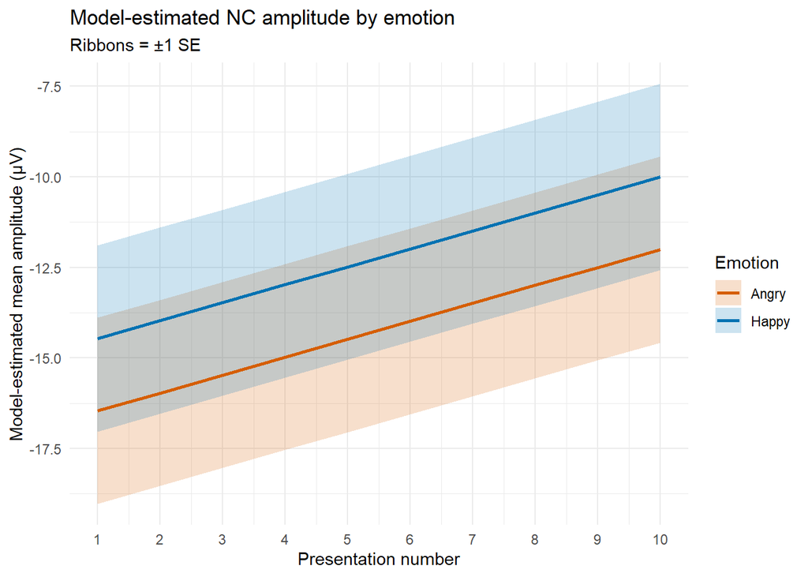

```r
# Same colors for each emotion in every plot
emotion_colors <- c(Angry = "#D55E00", Happy = "#0072B2")

# 1. Model-estimated mean amplitude for each emotion across presentations
emm_final <- emmeans(fit_final, ~ Emotion | PresentNum_True0,
                     at = list(PresentNum_True0 = 0:(n_presentations - 1)),
                     lmer.df = "asymptotic")   # > 3,000 trials: asymptotic df

as.data.frame(emm_final) %>%
  ggplot(aes(x = PresentNum_True0 + 1, y = emmean, color = Emotion, fill = Emotion)) +
  geom_ribbon(aes(ymin = emmean - SE, ymax = emmean + SE), alpha = 0.2, color = NA) +
  geom_line(linewidth = 1) +
  scale_x_continuous(breaks = 1:n_presentations) +
  scale_color_manual(values = emotion_colors) +
  scale_fill_manual(values = emotion_colors) +
  labs(x = "Presentation number", y = "Model-estimated mean amplitude (µV)",
       title = "Model-estimated NC amplitude by emotion",
       subtitle = "Ribbons = ±1 SE") +
  theme_minimal()
```

**Estimated marginal means for each emotion.** These are at the average presentation number and the average age. The gray lines show each child’s observed mean for context: the EMMs summarize the population, while the gray lines show how much children vary around it.

```r
# 2. EMMs for each emotion (at the average presentation number and age)
emm_emotion <- emmeans(fit_final, ~ Emotion, lmer.df = "asymptotic")
emm_emotion
```

```
##  Emotion emmean   SE  df asymp.LCL asymp.UCL
##  Angry    -14.2 2.56 Inf     -19.3     -9.21
##  Happy    -12.2 2.56 Inf     -17.3     -7.21
##
## Degrees-of-freedom method: asymptotic
## Confidence level used: 0.95
```

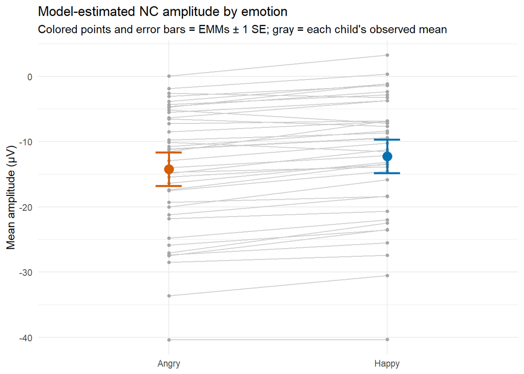

```r
# Each child's observed mean for each emotion
child_means <- sim_data %>%
  group_by(SubjectID, Emotion) %>%
  summarise(MeanAmp = mean(MeanAmp), .groups = "drop")

as.data.frame(emm_emotion) %>%
  ggplot(aes(x = Emotion, y = emmean, color = Emotion)) +
  geom_line(data = child_means, aes(y = MeanAmp, group = SubjectID),
            color = "grey80", linewidth = 0.4) +
  geom_point(data = child_means, aes(y = MeanAmp), color = "grey65", size = 1.2) +
  geom_errorbar(aes(ymin = emmean - SE, ymax = emmean + SE), width = 0.12, linewidth = 1) +
  geom_point(size = 4) +
  scale_color_manual(values = emotion_colors) +
  labs(x = NULL, y = "Mean amplitude (µV)",
       title = "Model-estimated NC amplitude by emotion",
       subtitle = "Colored points and error bars = EMMs ± 1 SE; gray = each child's observed mean") +
  theme_minimal() +
  theme(legend.position = "none")
```

**Estimated marginal means across age.** Age is a participant-level predictor, so each point is one child’s observed mean (one per emotion), and the lines are the model’s estimates across the age range.

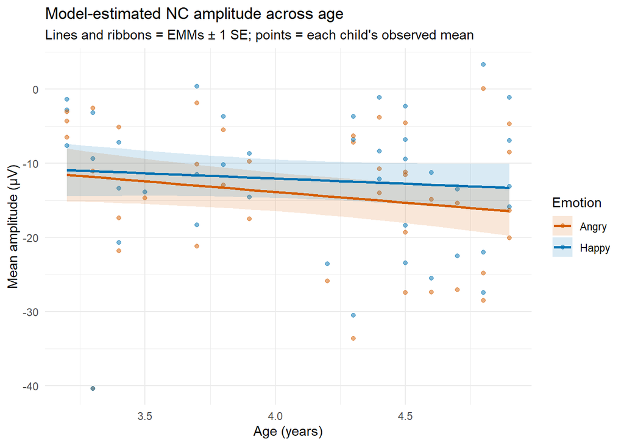

```r
# 3. EMMs across the observed age range (at the average presentation number)
age_grid <- seq(min(sim_data$Age_gmc), max(sim_data$Age_gmc), length.out = 25)
emm_age <- emmeans(fit_final, ~ Emotion | Age_gmc, at = list(Age_gmc = age_grid),
                   lmer.df = "asymptotic")

child_age_means <- sim_data %>%
  group_by(SubjectID, AgeYears, Emotion) %>%
  summarise(MeanAmp = mean(MeanAmp), .groups = "drop")

as.data.frame(emm_age) %>%
  mutate(AgeYears = Age_gmc + mean_age) %>%            # back to years for the x-axis
  ggplot(aes(x = AgeYears, y = emmean, color = Emotion, fill = Emotion)) +
  geom_point(data = child_age_means, aes(y = MeanAmp), alpha = 0.5, size = 1.5) +
  geom_ribbon(aes(ymin = emmean - SE, ymax = emmean + SE), alpha = 0.15, color = NA) +
  geom_line(linewidth = 1) +
  scale_color_manual(values = emotion_colors) +
  scale_fill_manual(values = emotion_colors) +
  labs(x = "Age (years)", y = "Mean amplitude (µV)",
       title = "Model-estimated NC amplitude across age",
       subtitle = "Lines and ribbons = EMMs ± 1 SE; points = each child's observed mean") +
  theme_minimal()
```

The lines aren’t parallel: the Happy − Angry difference is small in the youngest children and grows with age. That’s the Emotion × Age interaction. The age ribbons are wide because age is tested against only 40 children (df = 38), not ~4,000 trials.

**Two more figures for a paper:**

- **The grand-average waveform**, averaged across all children (with no casewise deletion), so readers can compare with earlier ERP studies. Our simulation only has mean amplitudes, so we can’t plot it here.
- **Single-trial waveforms from an example participant**, to show variability in single-trial data (can also go in Supplement for publications).

# 5 Going further with the final model

## 5.1 Circling back: dummy vs. effects coding

In Step 6, we said we’d come back to how Emotion is coded. Now that we have a final model, we can see what changes when we code it differently.

So far, `Emotion` has used R’s default **dummy (treatment) coding**: Angry = 0, Happy = 1. With dummy coding, every effect that interacts with emotion is that effect **in the reference group**. Our model has an Emotion × Age interaction, so the `Age_gmc` coefficient above is the age effect *for Angry faces only*.

If we want those effects **averaged across both emotions** (what most people mean by a “main effect”), we can use **effects coding** instead. There are two common versions:

- **±0.5:** Angry = −0.5, Happy = +0.5 (the two levels are 1 unit apart)
- **±1:** Angry = −1, Happy = +1 (the two levels are 2 units apart)

Here’s our final model fit all three ways. Presentation number and age are the same as before (0 = the first presentation; age centered), so coding is the only difference.

```r
# Effects coding: Angry = -0.5, Happy = +0.5
# Effects coding: Angry = -1,   Happy = +1
sim_data <- sim_data %>%
  mutate(Emotion_e  = ifelse(Emotion == "Happy", 0.5, -0.5),
         Emotion_e1 = ifelse(Emotion == "Happy", 1, -1))

# Dummy coding (Angry = 0, Happy = 1) is our final model, fit_final

fit_final_effects <- lmer(MeanAmp ~ Emotion_e * Age_gmc + PresentNum_True0 +
                            (1 | SubjectID) + (1 | ActorID),
                          data = sim_data)

fit_final_effects1 <- lmer(MeanAmp ~ Emotion_e1 * Age_gmc + PresentNum_True0 +
                             (1 | SubjectID) + (1 | ActorID),
                           data = sim_data)

# Same model, just reparameterized: the predictions are identical
all.equal(fitted(fit_final), fitted(fit_final_effects))
```

```
## [1] TRUE
```

```r
all.equal(fitted(fit_final), fitted(fit_final_effects1))
```

```
## [1] "Mean relative difference: 1.363336e-07"
```

**Another way: `contrasts()`.** Instead of making a new numeric variable, you can keep `Emotion` as a factor and change how R codes it:

```r
sim_data_c <- sim_data %>%
  mutate(Emotion = factor(Emotion, levels = c("Angry", "Happy")))
contrasts(sim_data_c$Emotion) <- c(-0.5, 0.5)   # Angry = -0.5, Happy = +0.5

lmer(MeanAmp ~ Emotion * Age_gmc + PresentNum_True0 +
       (1 | SubjectID) + (1 | ActorID),
     data = sim_data_c)
```

This gives the same estimates as `fit_final_effects`; only the coefficient’s name changes (`Emotion1` instead of `Emotion_e`). Keeping a factor is handy for predictors with 3+ levels, and `emmeans()` and plotting functions keep the level names (Angry, Happy). Two cautions:

- R’s built-in `contr.sum()` codes the **first** level as +1. With Angry first, that makes Angry = +1 and Happy = −1, so the Emotion coefficient flips sign (and is half the Happy − Angry difference). Setting the values yourself, as above, avoids this.
- The `||` shortcut for uncorrelated random effects only works with numeric predictors. If you need `(1 + Emotion_e || SubjectID)`, use the numeric version.

### 5.1.1 The output for each model

```r
# # Dummy coding: Angry = 0, Happy = 1
# summary(fit_final)
#
# # Effects coding: Angry = -0.5, Happy = +0.5
# summary(fit_final_effects)
#
# # Effects coding: Angry = -1, Happy = +1
# summary(fit_final_effects1)

# Side-by-side with sjPlot
tab_model(fit_final, fit_final_effects, fit_final_effects1,
          dv.labels = c("Dummy (Angry = 0, Happy = 1)",
                        "Effects (Angry = -0.5, Happy = +0.5)",
                        "Effects (Angry = -1, Happy = +1)"))
```

|  | Dummy (Angry = 0, Happy = 1) |  |  | Effects (Angry = -0.5, Happy = +0.5) |  |  | Effects (Angry = -1, Happy = +1) |  |  |
| --- | --- | --- | --- | --- | --- | --- | --- | --- | --- |
| Predictors | Estimates | CI | p | Estimates | CI | p | Estimates | CI | p |
| (Intercept) | -16.46 | -21.50 – -11.42 | **<0.001** | -15.46 | -20.50 – -10.43 | **<0.001** | -15.46 | -20.50 – -10.43 | **<0.001** |
| Emotion [Happy] | 2.00 | 1.50 – 2.49 | **<0.001** |  |  |  |  |  |  |
| Age gmc | -2.87 | -8.04 – 2.30 | 0.277 | -2.14 | -7.30 – 3.01 | 0.415 | -2.14 | -7.30 – 3.01 | 0.415 |
| PresentNum True0 | 0.50 | 0.41 – 0.58 | **<0.001** | 0.50 | 0.41 – 0.58 | **<0.001** | 0.50 | 0.41 – 0.58 | **<0.001** |
| Emotion [Happy] × Age gmc | 1.46 | 0.60 – 2.32 | **0.001** |  |  |  |  |  |  |
| Emotion e |  |  |  | 2.00 | 1.50 – 2.49 | **<0.001** |  |  |  |
| Emotion e × Age gmc |  |  |  | 1.46 | 0.60 – 2.32 | **0.001** |  |  |  |
| Emotion e1 |  |  |  |  |  |  | 1.00 | 0.75 – 1.25 | **<0.001** |
| Emotion e1 × Age gmc |  |  |  |  |  |  | 0.73 | 0.30 – 1.16 | **0.001** |
| Random Effects |  |  |  |  |  |  |  |  |  |
| σ<sup>2</sup> | 63.91 |  |  | 63.91 |  |  | 63.91 |  |  |
| τ<sub>00</sub> | 91.55 <sub>SubjectID</sub> |  |  | 91.55 <sub>SubjectID</sub> |  |  | 91.55 <sub>SubjectID</sub> |  |  |
|  | 21.26 <sub>ActorID</sub> |  |  | 21.26 <sub>ActorID</sub> |  |  | 21.26 <sub>ActorID</sub> |  |  |
| ICC | 0.64 |  |  | 0.64 |  |  | 0.64 |  |  |
| N | 40 <sub>SubjectID</sub> |  |  | 40 <sub>SubjectID</sub> |  |  | 40 <sub>SubjectID</sub> |  |  |
|  | 5 <sub>ActorID</sub> |  |  | 5 <sub>ActorID</sub> |  |  | 5 <sub>ActorID</sub> |  |  |
| Observations | 4000 |  |  | 4000 |  |  | 4000 |  |  |
| Marginal R<sup>2</sup> / Conditional R<sup>2</sup> | 0.026 / 0.648 |  |  | 0.026 / 0.648 |  |  | 0.026 / 0.648 |  |  |

### 5.1.2 All coefficients side by side

The three models name the emotion terms differently (`EmotionHappy`, `Emotion_e`, `Emotion_e1`), so we line them up by what each term is:

```r
# Pull the fixed effects from one model and label each term by its role
coef_by_role <- function(fit, emo, coding) {
  tidy(fit, effects = "fixed") %>%
    mutate(Term = case_when(
             term == "(Intercept)"                         ~ "Intercept",
             term == emo                                   ~ "Emotion",
             term == "PresentNum_True0"                 ~ "Presentation number",
             term == "Age_gmc"                               ~ "Age",
             term == paste0(emo, ":PresentNum_True0")   ~ "Emotion × Presentation number",
             term == paste0(emo, ":Age_gmc")                 ~ "Emotion × Age"),
           Coding = coding)
}

term_order <- c("Intercept", "Emotion", "Presentation number", "Age",
                "Emotion × Presentation number", "Emotion × Age")

# Line up the three codings of one model in a single table
coding_table <- function(fit_dummy, fit_e05, fit_e1) {
  coding_tab <- bind_rows(
      coef_by_role(fit_dummy, "EmotionHappy", "dummy"),
      coef_by_role(fit_e05,   "Emotion_e",    "e05"),
      coef_by_role(fit_e1,    "Emotion_e1",   "e1")) %>%
    transmute(Term = factor(Term, levels = term_order), Coding,
              b  = round(estimate, 3),
              SE = round(std.error, 3),
              t  = round(statistic, 2),
              p  = ifelse(p.value < .001, "< .001", sprintf("%.3f", p.value))) %>%
    pivot_wider(names_from = Coding, values_from = c(b, SE, t, p),
                names_glue = "{Coding}_{.value}") %>%
    arrange(Term) %>%
    select(Term, starts_with("dummy_"), starts_with("e05_"), starts_with("e1_"))

  kable(coding_tab, col.names = c("Term", rep(c("b", "SE", "t", "p"), 3))) %>%
    kable_styling(bootstrap_options = c("striped", "condensed"), full_width = FALSE) %>%
    add_header_above(c(" " = 1,
                       "Dummy (Angry = 0, Happy = 1)" = 4,
                       "Effects (Angry = -0.5, Happy = +0.5)" = 4,
                       "Effects (Angry = -1, Happy = +1)" = 4))
}

coding_table(fit_final, fit_final_effects, fit_final_effects1)
```

| Term | Dummy (Angry = 0, Happy = 1) b | Dummy (Angry = 0, Happy = 1) SE | Dummy (Angry = 0, Happy = 1) t | Dummy (Angry = 0, Happy = 1) p | Effects (Angry = -0.5, Happy = +0.5) b | Effects (Angry = -0.5, Happy = +0.5) SE | Effects (Angry = -0.5, Happy = +0.5) t | Effects (Angry = -0.5, Happy = +0.5) p | Effects (Angry = -1, Happy = +1) b | Effects (Angry = -1, Happy = +1) SE | Effects (Angry = -1, Happy = +1) t | Effects (Angry = -1, Happy = +1) p |
| --- | --- | --- | --- | --- | --- | --- | --- | --- | --- | --- | --- | --- |
| Intercept | -16.463 | 2.571 | -6.40 | < .001 | -15.464 | 2.568 | -6.02 | < .001 | -15.464 | 2.568 | -6.02 | < .001 |
| Emotion | 1.998 | 0.253 | 7.91 | < .001 | 1.998 | 0.253 | 7.91 | < .001 | 0.999 | 0.126 | 7.91 | < .001 |
| Presentation number | 0.495 | 0.044 | 11.25 | < .001 | 0.495 | 0.044 | 11.25 | < .001 | 0.495 | 0.044 | 11.25 | < .001 |
| Age | -2.871 | 2.638 | -1.09 | 0.283 | -2.142 | 2.629 | -0.81 | 0.420 | -2.142 | 2.629 | -0.81 | 0.420 |
| Emotion × Age | 1.459 | 0.438 | 3.33 | < .001 | 1.459 | 0.438 | 3.33 | < .001 | 0.729 | 0.219 | 3.33 | < .001 |

```r
b_dum <- fixef(fit_final)
b_eff <- fixef(fit_final_effects)
b_ef1 <- fixef(fit_final_effects1)
```

### 5.1.3 What changed and what didn’t?

| Coefficient | Dummy (0/1) | Effects (±0.5) | Effects (±1) |
| --- | --- | --- | --- |
| Intercept | Angry faces, first presentation, average age: -16.46 µV | Average of Happy and Angry: -15.46 µV | Same as ±0.5: -15.46 µV |
| Emotion | Happy − Angry: 2 µV | Happy − Angry: 2 µV | **Half** of Happy − Angry: 1 µV |
| Presentation number | Habituation (both emotions): 0.495 µV | Same: 0.495 µV | Same: 0.495 µV |
| Age | Age effect for **Angry**: -2.87 µV | Age effect **averaged** over emotions: -2.14 µV | Same as ±0.5: -2.14 µV |
| Emotion × Age | Happy age effect − Angry age effect: 1.459 | Same as dummy: 1.459 | **Half** of that: 0.729 |

**Dummy vs. effects coding changes the lower-order effects that interact with emotion** (the intercept and age). The effects-coded age effect sits halfway between the Angry and Happy age effects, so it equals the dummy-coded (Angry) age effect + ½ × the Emotion × Age interaction: -2.87 + ½ × 1.46 = -2.14 µV. (We simulated -2.75 µV per year for Angry faces and -2 µV per year averaged over emotions. With only 40 children, age is estimated imprecisely, so in another sample these estimates could land far from the simulated values; see the fixed-effects interpretation above.) Its *p*-value changes too, because it’s now testing a different question (the average age effect instead of the Angry one). Presentation number doesn’t interact with emotion, so it’s the same in all three.

**±0.5 vs. ±1 only rescales the emotion terms.** Happy and Angry are 2 units apart with ±1 coding, so the emotion coefficient (and every interaction with emotion) is the change per unit, which is *half* the Happy − Angry difference. The SEs are halved too, so the *t* and *p* values are identical to ±0.5. The intercept and the presentation number and age effects don’t change at all.

**Which age effect would you report?** With dummy coding, “the age effect” is really the age effect for Angry faces, which is steeper than for Happy faces. Reporting it as *the* age effect would overstate how much NC amplitude changes with age in general. The effects-coded estimate is the average over both emotions.

### 5.1.4 Marginal means don’t depend on coding

Instead of refitting with a different coding, you can keep the dummy-coded `fit_final` and get the effects you want from **estimated marginal means** (EMMs). `emmeans()` gives the model-estimated Nc for each emotion, and `emtrends()` gives the age effect (slope) for each emotion. These are predictions from the model, so they’re the same no matter how Emotion is coded.

```r
# Model-estimated mean Nc for each emotion (at the average age and presentation number)
emm_coding <- emmeans(fit_final, ~ Emotion, lmer.df = "asymptotic")
emm_coding
```

```
##  Emotion emmean   SE  df asymp.LCL asymp.UCL
##  Angry    -14.2 2.56 Inf     -19.3     -9.21
##  Happy    -12.2 2.56 Inf     -17.3     -7.21
##
## Degrees-of-freedom method: asymptotic
## Confidence level used: 0.95
```

```r
pairs(emm_coding, reverse = TRUE)   # Happy - Angry
```

```
##  contrast      estimate    SE  df z.ratio p.value
##  Happy - Angry        2 0.253 Inf   7.905  <.0001
##
## Degrees-of-freedom method: asymptotic
```

```r
# Age effect (µV per year) for each emotion, and averaged over both
emt_coding <- emtrends(fit_final, ~ Emotion, var = "Age_gmc", lmer.df = "asymptotic")
emt_coding
```

```
##  Emotion Age_gmc.trend   SE  df asymp.LCL asymp.UCL
##  Angry           -2.87 2.64 Inf     -8.04      2.30
##  Happy           -1.41 2.64 Inf     -6.58      3.76
##
## Degrees-of-freedom method: asymptotic
## Confidence level used: 0.95
```

```r
emtrends(fit_final, ~ 1, var = "Age_gmc", lmer.df = "asymptotic")
```

```
##  1       Age_gmc.trend   SE  df asymp.LCL asymp.UCL
##  overall         -2.14 2.63 Inf     -7.29      3.01
##
## Results are averaged over the levels of: Emotion
## Degrees-of-freedom method: asymptotic
## Confidence level used: 0.95
```

- **Emotion:** at the average age and presentation number, Happy faces elicited a less negative Nc than Angry faces (Happy − Angry = 2.00 µV).
- **Age:** the age effect is -2.87 µV per year for Angry faces and -1.41 µV per year for Happy faces, or -2.14 µV per year averaged over both. These match the coefficients above: the dummy-coded `Age_gmc` is the Angry slope, and the effects-coded `Age_gmc` is the average.

## 5.2 Centering

**Presentation number.** The intercept above is for the first presentation. To get it at the **average** presentation instead, we re-fit the model with `PresentNum_gmc` (presentation number minus its mean, 5.5):

```r
fit_final_centered <- lmer(MeanAmp ~ Emotion * Age_gmc + PresentNum_gmc +
                             (1 | SubjectID) + (1 | ActorID),
                           data = sim_data)

# Side-by-side: first presentation = 0 vs. average presentation = 0
tab_model(fit_final, fit_final_centered,
          dv.labels = c("PresentNum_True0", "PresentNum_gmc"))
```

|  | PresentNum_True0 |  |  | PresentNum_gmc |  |  |
| --- | --- | --- | --- | --- | --- | --- |
| Predictors | Estimates | CI | p | Estimates | CI | p |
| (Intercept) | -16.46 | -21.50 – -11.42 | **<0.001** | -14.23 | -19.26 – -9.21 | **<0.001** |
| Emotion [Happy] | 2.00 | 1.50 – 2.49 | **<0.001** | 2.00 | 1.50 – 2.49 | **<0.001** |
| Age gmc | -2.87 | -8.04 – 2.30 | 0.277 | -2.87 | -8.04 – 2.30 | 0.277 |
| PresentNum True0 | 0.50 | 0.41 – 0.58 | **<0.001** |  |  |  |
| Emotion [Happy] × Age gmc | 1.46 | 0.60 – 2.32 | **0.001** | 1.46 | 0.60 – 2.32 | **0.001** |
| PresentNum gmc |  |  |  | 0.50 | 0.41 – 0.58 | **<0.001** |
| Random Effects |  |  |  |  |  |  |
| σ<sup>2</sup> | 63.91 |  |  | 63.91 |  |  |
| τ<sub>00</sub> | 91.55 <sub>SubjectID</sub> |  |  | 91.55 <sub>SubjectID</sub> |  |  |
|  | 21.26 <sub>ActorID</sub> |  |  | 21.26 <sub>ActorID</sub> |  |  |
| ICC | 0.64 |  |  | 0.64 |  |  |
| N | 40 <sub>SubjectID</sub> |  |  | 40 <sub>SubjectID</sub> |  |  |
|  | 5 <sub>ActorID</sub> |  |  | 5 <sub>ActorID</sub> |  |  |
| Observations | 4000 |  |  | 4000 |  |  |
| Marginal R<sup>2</sup> / Conditional R<sup>2</sup> | 0.026 / 0.648 |  |  | 0.026 / 0.648 |  |  |

```r
b_cen <- fixef(fit_final_centered)
```

Only the intercept changes (-16.46 → -14.23 µV): presentation number doesn’t interact with anything, so the emotion effect, the age effect, and the interaction are identical. This is what Step 6 said: without an interaction, centering only changes the intercept.

**Age.** Age *does* interact with emotion, so where age = 0 sits changes the meaning of the emotion effect. With raw age in years, `EmotionHappy` would be the emotion effect at age 0, a newborn, far outside our 3-to-5-year-olds:

Without centering, the emotion coefficient (dummy coded) shows that Happy faces would be about 4 µV more negative than Angry faces in a newborn. That’s the opposite direction of the +2.00 at the average age.

```r
fit_final_rawage <- lmer(MeanAmp ~ Emotion * AgeYears + PresentNum_gmc +
                           (1 | SubjectID) + (1 | ActorID),
                         data = sim_data)

bind_rows(`Age_gmc (0 = average age)` = tidy(fit_final_centered, effects = "fixed"),
          `AgeYears (0 = newborn)`   = tidy(fit_final_rawage, effects = "fixed"),
          .id = "Model") %>%
  filter(term == "EmotionHappy") %>%
  select(Model, estimate, std.error, statistic) %>%
  kable(digits = 2, col.names = c("Model", "EmotionHappy (µV)", "SE", "t value")) %>%
  kable_styling(full_width = FALSE)
```

| Model | EmotionHappy (µV) | SE | t value |
| --- | --- | --- | --- |
| Age_gmc (0 = average age) | 2.00 | 0.25 | 7.91 |
| AgeYears (0 = newborn) | -4.02 | 1.82 | -2.20 |

```r
b_rawage <- fixef(fit_final_rawage)
```

## 5.3 Standardized betas as an effect size

Raw coefficients are in different units (µV per presentation, µV per year), so they’re hard to compare with each other or across studies. **Standardized betas** (β) put every effect in standard deviation (SD) units: the change in amplitude, in SDs, for a 1-SD change in the predictor. To get them, we standardize every variable (including mean amplitude) with `scale()` (subtract the mean, divide by the SD), name each one `_z`, and refit the final model:

```r
# Age is a child-level variable: scale it with one value per child, so children
# with more trials don't count more toward the mean and SD
age_z <- sim_data %>%
  distinct(SubjectID, AgeYears) %>%
  mutate(Age_z = as.numeric(scale(AgeYears))) %>%
  select(SubjectID, Age_z)

# Trial-level variables: scale across all trials
sim_data_z <- sim_data %>%
  left_join(age_z, by = "SubjectID") %>%
  mutate(MeanAmp_z    = as.numeric(scale(MeanAmp)),
         PresentNum_z = as.numeric(scale(PresentNum)),
         Emotion_z    = as.numeric(scale(Emotion == "Happy")))   # balanced design, so Angry = -1, Happy = +1

# The final model, with standardized variables
fit_final_z <- lmer(MeanAmp_z ~ Emotion_z * Age_z + PresentNum_z +
                      (1 | SubjectID) + (1 | ActorID),
                    data = sim_data_z)

# Standardized betas with 95% CIs
beta_tab <- tidy(fit_final_z, effects = "fixed", conf.int = TRUE) %>%
  filter(term != "(Intercept)")
beta_tab %>%
  transmute(Predictor = term,
            `β` = round(estimate, 3),
            `95% CI` = sprintf("[%.3f, %.3f]", conf.low, conf.high),
            p = ifelse(p.value < .001, "< .001", sprintf("%.3f", p.value))) %>%
  kable() %>%
  kable_styling(bootstrap_options = c("striped", "condensed"), full_width = FALSE)
```

| Predictor | β | 95% CI | p |
| --- | --- | --- | --- |
| Emotion_z | 0.076 | [0.057, 0.095] | < .001 |
| Age_z | -0.095 | [-0.332, 0.142] | 0.420 |
| PresentNum_z | 0.108 | [0.089, 0.127] | < .001 |
| Emotion_z:Age_z | 0.032 | [0.013, 0.052] | < .001 |

```r
b_z <- setNames(beta_tab$estimate, beta_tab$term)
```

How to read them:

- **Presentation number, β = 0.11:** for each 1-SD increase in presentation number (2.9 presentations), amplitude changes by 0.11 SDs.
- **Age, β = -0.1:** for each 1-SD increase in age (0.58 years), amplitude changes by -0.1 SDs.
- **Emotion, β = 0.08:** emotion is binary, so a “1-SD change” is less intuitive. With a balanced design, `Emotion_z` is −1 for Angry and +1 for Happy (2 units apart), so the Happy − Angry difference is 2 × β = 0.15 SDs. If you’d rather report the full difference directly, keep emotion at ±0.5 and standardize only the outcome and the continuous predictors.

### 5.3.1 Checking the emotion effect with emmeans

Three ways to get the Happy − Angry difference in SD units should all agree:

1. **2 × β** from the fully standardized model (`Emotion_z` = −1 / +1).
2. **The coefficient** from a model with emotion kept at **±0.5** (only the outcome and the continuous predictors standardized). Angry and Happy are 1 unit apart, so no transformation is needed.
3. **The pairwise comparison** of the estimated marginal means (EMMs) from the raw model (in µV), divided by the SD of mean amplitude.

```r
# 2. Emotion at +/-0.5; outcome, age, and presentation number standardized
fit_final_z05 <- lmer(MeanAmp_z ~ Emotion_e * Age_z + PresentNum_z +
                        (1 | SubjectID) + (1 | ActorID),
                      data = sim_data_z)

# EMMs at Angry (-0.5) and Happy (+0.5), for average age and presentation number
emm_z05 <- emmeans(fit_final_z05, ~ Emotion_e, at = list(Emotion_e = c(-0.5, 0.5)),
                   lmer.df = "asymptotic")
emm_z05
```

```
##  Emotion_e  emmean    SE  df asymp.LCL asymp.UCL
##       -0.5 -0.0761 0.195 Inf    -0.459     0.306
##        0.5  0.0761 0.195 Inf    -0.306     0.459
##
## Degrees-of-freedom method: asymptotic
## Confidence level used: 0.95
```

```r
pairs(emm_z05, reverse = TRUE)   # Happy - Angry, in SDs of amplitude
```

```
##  contrast                       estimate     SE  df z.ratio p.value
##  Emotion_e0.5 - (Emotion_e-0.5)    0.152 0.0192 Inf   7.905  <.0001
##
## Degrees-of-freedom method: asymptotic
```

```r
# 3. The same comparison on the raw model, in µV
emm_raw <- emmeans(fit_final, ~ Emotion, lmer.df = "asymptotic")
emm_raw
```

```
##  Emotion emmean   SE  df asymp.LCL asymp.UCL
##  Angry    -14.2 2.56 Inf     -19.3     -9.21
##  Happy    -12.2 2.56 Inf     -17.3     -7.21
##
## Degrees-of-freedom method: asymptotic
## Confidence level used: 0.95
```

```r
diff_raw <- pairs(emm_raw, reverse = TRUE)   # Happy - Angry, in µV
diff_raw
```

```
##  contrast      estimate    SE  df z.ratio p.value
##  Happy - Angry        2 0.253 Inf   7.905  <.0001
##
## Degrees-of-freedom method: asymptotic
```

```r
# All three, side by side
tibble(Method = c("2 × β (Emotion_z = −1 / +1)",
                  "Coefficient (Emotion = ±0.5, outcome standardized)",
                  "EMM difference in µV ÷ SD of mean amplitude"),
       `Happy − Angry (SD units)` = round(c(2 * fixef(fit_final_z)[["Emotion_z"]],
                                            fixef(fit_final_z05)[["Emotion_e"]],
                                            summary(diff_raw)$estimate / sd(sim_data$MeanAmp)), 3)) %>%
  kable() %>%
  kable_styling(bootstrap_options = c("striped", "condensed"), full_width = FALSE)
```

| Method | Happy − Angry (SD units) |
| --- | --- |
| 2 × β (Emotion_z = −1 / +1) | 0.152 |
| Coefficient (Emotion = ±0.5, outcome standardized) | 0.152 |
| EMM difference in µV ÷ SD of mean amplitude | 0.152 |

All three give the same Happy − Angry difference, 0.15 SDs: Happy faces elicited an Nc 0.15 SDs less negative than Angry faces (for a child of average age). The EMMs and their pairwise comparison work on the raw model too, which is often the easiest way to report a condition difference: in µV (2 µV) and, if you need it, in SD units.

A few things to keep in mind:

- **The t and p values don’t change.** Standardizing only rescales each variable, so the tests are the same as in the unstandardized model.
- **The “SD” is the total SD of amplitude**, which includes differences between children and actors, not just trial-to-trial noise. Standardized betas from an LME aren’t directly comparable to Cohen’s *d* from a *t*-test on averaged data.
- **Report both**: unstandardized b (in µV, which ERP readers can picture) and standardized β (to compare effects and studies).

## 5.4 Reporting in APA style

**My recommendation:** put every fixed effect in a **table** (maybe in Supplement), and in the text report *b*, *SE*, *p*, and β for the effects you discuss.

The table below uses the effects-coded final model (`fit_final_effects`), so each term is averaged over emotions, and the standardized β’s from `fit_final_z` in the section above.

```r
# APA formatting helpers: 2 decimals with a real minus sign; p with 3 decimals and no leading zero
f2 <- function(x) sub("-", "−", sprintf("%.2f", x))
fp <- function(p) ifelse(p < .001, "< .001", sub("^0", "", sprintf("%.3f", p)))

raw_tab <- tidy(fit_final_effects, effects = "fixed", conf.int = TRUE)   # b, SE, 95% CI, t, df, p
std_tab <- tidy(fit_final_z, effects = "fixed")                          # beta (same term order)

apa_tab <- raw_tab %>%
  mutate(beta = std_tab$estimate) %>%
  transmute(Predictor = c("Intercept", "Emotion (Happy − Angry)", "Age (years, centered)",
                          "Presentation number", "Emotion × Age"),
            b = f2(estimate),
            SE = f2(std.error),
            `95% CI` = paste0("[", f2(conf.low), ", ", f2(conf.high), "]"),
            t = f2(statistic),
            df = ifelse(abs(df - round(df)) < .005, sprintf("%.0f", df), sprintf("%.2f", df)),
            p = fp(p.value),
            `β` = ifelse(term == "(Intercept)", "", f2(beta)))

apa_tab %>%
  kable(caption = "Fixed effects of the final model (effects coding: Angry = −0.5, Happy = +0.5)") %>%
  kable_styling(bootstrap_options = c("striped", "condensed"), full_width = FALSE)
```

Fixed effects of the final model (effects coding: Angry = −0.5, Happy = +0.5)

| Predictor | b | SE | 95% CI | t | df | p | β |
| --- | --- | --- | --- | --- | --- | --- | --- |
| Intercept | −15.46 | 2.57 | [−21.25, −9.68] | −6.02 | 9.27 | < .001 |  |
| Emotion (Happy − Angry) | 2.00 | 0.25 | [1.50, 2.49] | 7.91 | 3953 | < .001 | 0.08 |
| Age (years, centered) | −2.14 | 2.63 | [−7.46, 3.18] | −0.81 | 38 | .420 | −0.10 |
| Presentation number | 0.50 | 0.04 | [0.41, 0.58] | 11.25 | 3953 | < .001 | 0.11 |
| Emotion × Age | 1.46 | 0.44 | [0.60, 2.32] | 3.33 | 3953 | < .001 | 0.03 |

```r
age_raw <- filter(raw_tab, term == "Age_gmc")
age_std <- filter(std_tab, term == "Age_z")
```

**In the text**, for the age effect:

> Averaged over emotions, age was not significantly associated with Nc amplitude, *b* = −2.14, *SE* = 2.63, *p* = .420, β = −0.10 (see Table 1).

## 5.5 Random effects

These random-effect estimates are identical for `fit_final` and `fit_final_centered`: centering a fixed-effect predictor doesn’t change the random intercept variances when the model has no random slopes.

If we’re interested in what variance is attributed to participant variability vs. actor variability we can run:

```r
icc(fit_final, by_group = T)
```

```
## # ICC by Group
##
## Group     |   ICC
## -----------------
## SubjectID | 0.518
## ActorID   | 0.120
```

# 6 Common errors

## 6.1 Error 1: Misspecifying the random-effects grouping structure

A subtler error: treating a within-subjects/crossed factor as if it were a simple grouping factor, or vice versa. For example, `Emotion` in our design is **crossed** with participants (everyone sees both emotions) — it should never appear as a *grouping* variable like `(1 | Emotion)`, only inside the random-effects term as a variable that’s allowed to have a random *slope* (e.g. `(1 + Emotion | SubjectID)`). Writing `(1 | Emotion)` fits a model that treats “Happy” and “Angry” as if they were two random draws from a larger population of possible emotions — nonsensical here, since we deliberately chose these two conditions:

```r
fit_wrong_grouping <- lmer(MeanAmp ~ PresentNum + Age_gmc + (1 | SubjectID) + (1 | Emotion),
                            data = sim_data, REML = TRUE)
summary(fit_wrong_grouping)
```

```
## Linear mixed model fit by REML. t-tests use Satterthwaite's method ['lmerModLmerTest']
## Formula: MeanAmp ~ PresentNum + Age_gmc + (1 | SubjectID) + (1 | Emotion)
##    Data: sim_data
##
## REML criterion at convergence: 29129.9
##
## Scaled residuals:
##     Min      1Q  Median      3Q     Max
## -3.1300 -0.6627  0.0272  0.6819  3.3227
##
## Random effects:
##  Groups    Name        Variance Std.Dev.
##  SubjectID (Intercept) 91.377   9.559
##  Emotion   (Intercept)  1.956   1.399
##  Residual              81.258   9.014
## Number of obs: 4000, groups:  SubjectID, 40; Emotion, 2
##
## Fixed effects:
##               Estimate Std. Error         df t value Pr(>|t|)
## (Intercept)  -15.95881    1.83230    9.91715  -8.710 5.87e-06 ***
## PresentNum     0.49528    0.04962 3958.00001   9.981  < 2e-16 ***
## Age_gmc       -2.14166    2.62885   37.99993  -0.815     0.42
## ---
## Signif. codes:  0 '***' 0.001 '**' 0.01 '*' 0.05 '.' 0.1 ' ' 1
##
## Correlation of Fixed Effects:
##            (Intr) PrsntN
## PresentNum -0.149
## Age_gmc     0.000  0.000
```

Notice `Emotion` now has only 2 levels in its random-effect variance component — R will fit this without erroring, which is exactly what makes it dangerous. **A grouping factor with fewer than ~5 levels should almost never be modeled as a random effect** (Volpert-Esmond et al., 2021); instead it belongs as a *fixed* effect, as in our final model (`fit_final`). Always sanity-check `summary(fit)$ngrps` or `VarCorr(fit)` to confirm the number of levels going into each random-effect grouping factor matches what you intended.

```r
summary(fit_final)$ngrps
```

```
## SubjectID   ActorID
##        40         5
```

## 6.2 Error 2: Splitting one grouping factor across random-effects terms

It’s tempting to write each random slope in its own set of parentheses, e.g. `(1 + Emotion | SubjectID) + (1 + PresentNum_True0 | SubjectID)`. But each set of parentheses includes its own `1`, so this fits **two separate random intercepts** for SubjectID, which the model can’t tell apart. It splits the participant intercept variance across the two terms (`SubjectID` and `SubjectID.1` below) and is itself a cause of singular fits:

```r
fit_dup <- lmer(MeanAmp ~ Emotion * PresentNum_True0 + Emotion * Age_gmc +
                  (1 + Emotion | SubjectID) + (1 + PresentNum_True0 | SubjectID) +
                  (1 | ActorID),
                data = sim_data)
check_fit(fit_dup)
```

```
## Singular fit: TRUE
##
##  Groups      Name             Std.Dev. Corr
##  SubjectID   (Intercept)      7.438360
##              EmotionHappy     0.121593 -1.000
##  SubjectID.1 (Intercept)      6.207843
##              PresentNum_True0 0.026985 -1.000
##  ActorID     (Intercept)      4.609183
##  Residual                     7.994466
```

Put all slopes for a grouping factor in one term: `(1 + Emotion + PresentNum_True0 | SubjectID)`. If you want a slope *without* its own intercept, use `0 +`, e.g. `(1 + Emotion | SubjectID) + (0 + PresentNum_True0 | SubjectID)`.

# 7 About these materials

These materials were developed for the Society for Psychophysiological Research pre-conference workshop “Linear mixed effects models for event-related potential research” (October 14, 2026, Halifax, Canada) by Megan J. Heise.

**Please cite as:** Heise, M. J. (2026, October 14). *Linear mixed effects models for event-related potential research* [Workshop materials]. Society for Psychophysiological Research Annual Meeting, Halifax, Nova Scotia, Canada.

# 8 Helpful articles for more discussions of mixed effects models & examples

- Heise, M. J., Mon, S. K., & Bowman, L. C. (2022). Utility of linear mixed effects models for event-related potential research with infants and children. *Developmental Cognitive Neuroscience, 54*, 101070. https://doi.org/10.1016/j.dcn.2022.101070
- Tutorial scripts and example data: https://github.com/basclab/LME_MixedEffectsERPTutorial
- Barr, D. J., Levy, R., Scheepers, C., & Tily, H. J. (2013). Random effects structure for confirmatory hypothesis testing: Keep it maximal. *Journal of Memory and Language, 68*(3), 255–278.
- Brauer, M., & Curtin, J. J. (2018). Linear mixed-effects models and the analysis of nonindependent data. *Psychological Methods, 23*(3), 389–411.
- Matuschek, H., Kliegl, R., Vasishth, S., Baayen, H., & Bates, D. (2017). Balancing Type I error and power in linear mixed models. *Journal of Memory and Language, 94*, 305–315.
- Volpert-Esmond, H. I., Page-Gould, E., & Bartholow, B. D. (2021). Using multilevel models for the analysis of event-related potentials. *International Journal of Psychophysiology, 162*, 145–156.
- Schielzeth, H., Dingemanse, N. J., Nakagawa, S., Westneat, D. F., Allegue, H., Teplitsky, C., Réale, D., Dochtermann, N. A., Garamszegi, L. Z., & Araya-Ajoy, Y. G. (2020). Robustness of linear mixed-effects models to violations of distributional assumptions. *Methods in Ecology and Evolution, 11*(9), 1141–1152.
- Kristjansson, S. D., Kircher, J. C., & Webb, A. K. (2007). Multilevel models for repeated measures research designs in psychophysiology: An introduction to growth curve modeling. Psychophysiology, 44(5), 728-736. https://doi.org/10.1111/j.1469-8986.2007.00544.x
- Page-Gould, E. (2017). Multilevel modeling. In J. T. Cacioppo, L. G. Tassinary, & G. G. Berntson (Eds.), Handbook of psychophysiology (4th ed., pp. 662–678). Cambridge University Press.
- Tremblay, A., & Newman, A. J. (2015). Modeling nonlinear relationships in ERP data using mixed-effects regression with R examples. Psychophysiology, 52(1), 124-139. https://doi.org/10.1111/psyp.12299
- Vossen, H., van Breukelen, G., Hermens, H., van Os, J., & Lousberg, R. (2011). More potential in statistical analyses of event-related potentials: A mixed regression approach. International Journal of Methods in Psychiatric Research, 20(3), e56-e68. https://doi.org/10.1002/mpr.348
- Mon, S. K., Manning, B. L., Wakschlag, L. S., & Norton, E. S. (2024). Leveraging mixed-effects location scale models to assess the ERP mismatch negativity’s psychometric properties and trial-by-trial neural variability in toddler-mother dyads. Developmental Cognitive Neuroscience, 70, Article 101459. https://doi.org/10.1016/j.dcn.2024.101459